# Volcano plots with ggplot2

data visualisation

ggplot2

tidyverse

R

Revising my grammar of graphics.

Erika Duan  
01-02-2021

# Introduction

In 2018, whilst still an R newbie, I participated in the [RLadies Melbourne community lightning talks](https://github.com/R-LadiesMelbourne/2018-10-16_How-R-You) and talked about how to visualise volcano plots in R. Volcano plots are probably an obscure concept outside of bioinformatics, but their construction nicely showcases the elegance of `ggplot2`.

In the last two years, a number of small and handy functions have been added to `dplyr` and `ggplot2`, which this post has been updated to reflect. [^1]

Let’s get started then.

```r
# Load required packages -------------------------------------------------------
if (!require("pacman")) install.packages("pacman")
pacman::p_load(here,
               tidyverse,
               janitor, # Cleaning column names
               scales, # Transform axis scales
               ggrepel) # Optimise plot label separation
```

# Import a test dataset

This is a dataset with four columns:

- **Entrez ID** - stores the unique gene ID.
- **Gene symbol** - stores the gene name associated with an unique Entrez ID.
- **Fold change** - stores the change in gene expression level detected in diseased versus healthy tissue.
- **Adjusted P-value** - stores the P-value adjusted with a false discovery rate (FDR) correction for multiple testing.

Every row represents a unique gene expression fold change, which fulfills tidy data requirements for creating data visualisations.

**Note:** The data used originates from [Fu et al. Nat Cell Biol. 2015](https://pubmed.ncbi.nlm.nih.gov/25730472/) and a copy of the original dataset can be found [here](https://zenodo.org/record/2529117#.X-_obzTis2w).

```r
# Import and clean dataset -----------------------------------------------------
diseased_vs_healthy <- read.delim(here("data", "luminal-pregnant-vs-lactate.txt"),
                                  header = TRUE,
                                  sep = "\t")

diseased_vs_healthy <- janitor::clean_names(diseased_vs_healthy)

diseased_vs_healthy <- diseased_vs_healthy %>%
  mutate(fold_change = 2^log_fc) %>%
  select(entrezid,
         symbol,
         fold_change,
         adj_p_val)
```

| entrezid | symbol | fold_change | adj_p_val |
| --- | --- | --- | --- |
| 14367 | Fzd5 | 2.0716416 | 0.0542520 |
| 244144 | Usp35 | 0.4197075 | 0.0598292 |
| 100216534 | Snord96a | 1.2373480 | 0.9999999 |
| 66151 | Prr13 | 1.4296409 | 0.9999999 |
| 229445 | Ctso | 1.0506197 | 0.9999999 |

# Create a simple volcano plot

A basic version of a volcano plot depicts:

- Along its x-axis: `log2(fold_change)`
- Along its y-axis: `-log10(adj_p_val)`

**Note:** The y-axis depicts -log10(adj_p_val), which allows the points on the plot to project upwards as the fold change greatly increases or decreases. This is more intuitive to visualise, the data points at the edges of the ‘volcano spray’ are the most interesting ones.

The versatility of `ggplot2` also means that you don’t need to store data transformations as separate variables for plotting. You can apply transformations directly inside `ggplot(data, aes(x, y))` or alternatively by using `scale_x_continuous(trans = "...")` or `coord_trans(x, y)`.

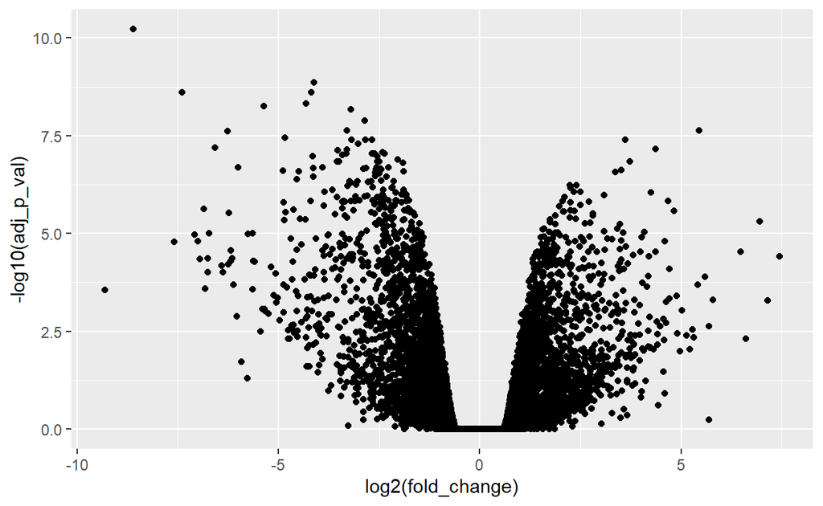

```r
# Create a simple volcano plot -------------------------------------------------
vol_plot <- diseased_vs_healthy %>%
  ggplot(aes(x = log2(fold_change),
             y = -log10(adj_p_val))) +
  geom_point()

vol_plot # Visualise simple volcano plot
```

**Note:** For single layer plots, use `%>%` pipes with `ggplot2` functions for convenience and readability.

# Add horizontal and vertical plot lines

The functions `geom_hline()` and `geom_vline()` can be used to add extra horizontal and vertical lines on your plot respectively. In this example, I am interested in constructing boundaries for genes which have `adj_p_val <= 0.05` and `fold_change <= 0.5` or `fold_change >= 2`.

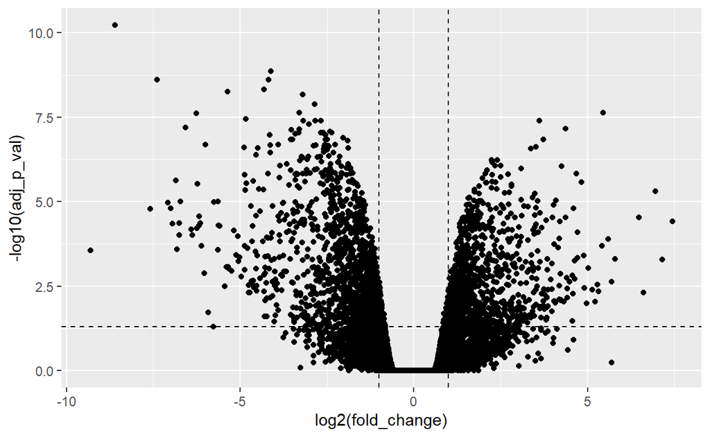

```r
# Plot extra quadrants ---------------------------------------------------------
vol_plot +
  geom_hline(yintercept = -log10(0.05),
             linetype = "dashed") +
  geom_vline(xintercept = c(log2(0.5), log2(2)),
             linetype = "dashed")
```

# Modify the x-axis and y-axis

Volcano plots should have a symmetrical x-axis. One way you can do this is by manually setting the limits of the x-axis using `xlim(min, max)`.

```r
# Identify xlim() values -------------------------------------------------------
diseased_vs_healthy %>%
  pull(fold_change) %>%
  min() %>%
  log2() %>%
  floor()
```

```
#> [1] -10
```

```r
diseased_vs_healthy %>%
  pull(fold_change) %>%
  max() %>%
  log2() %>%
  ceiling()
```

```
#> [1] 8
```

```r
max(abs(-10), abs(8))
```

```
#> [1] 10
```

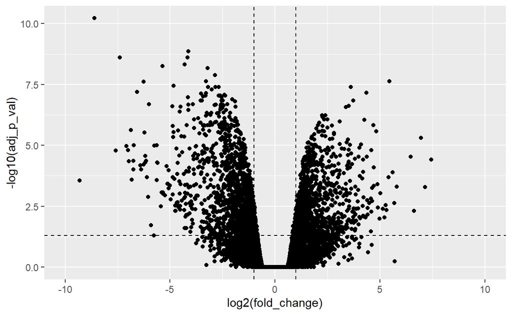

```r
# Change xlim() ----------------------------------------------------------------
# Manually specify x-axis limits
vol_plot +
  geom_hline(yintercept = -log10(0.05),
             linetype = "dashed") +
  geom_vline(xintercept = c(log2(0.5), log2(2)),
             linetype = "dashed") +
  xlim(-10, 10)
```

You can also change the limits of the x-axis inside `scale_x_continuous`. This method also gives you the flexibility to fine-tune the spacing and labelling of axis tick marks.

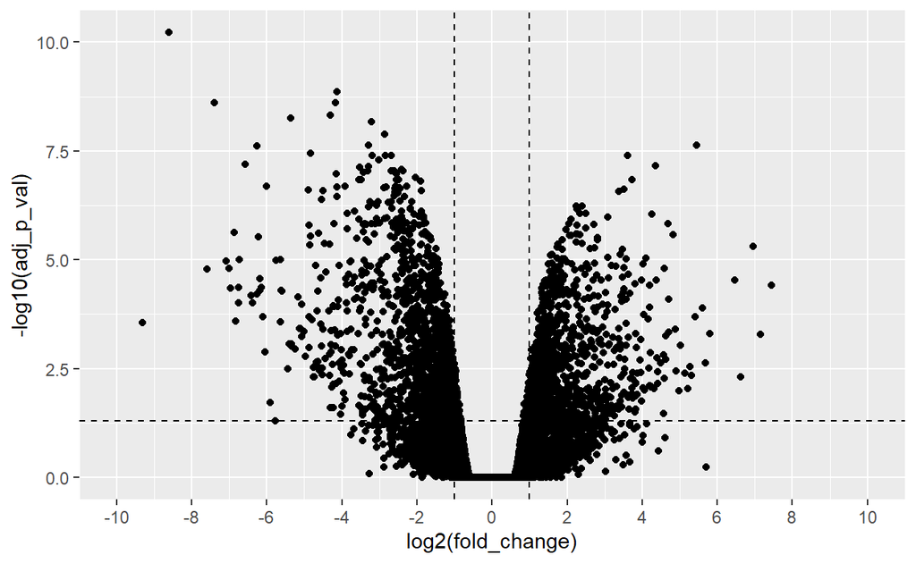

```r
# Modify scale_x_continuous() --------------------------------------------------
vol_plot +
  geom_hline(yintercept = -log10(0.05),
             linetype = "dashed") +
  geom_vline(xintercept = c(log2(0.5), log2(2)),
             linetype = "dashed") +
  scale_x_continuous(breaks = c(seq(-10, 10, 2)), # Modify x-axis tick intervals
                     limits = c(-10, 10))
```

**Note:** The value specified inside the argument `scale_continuous_x(limits = ...)` supersedes the range of values specified inside the argument `scale_continuous_x(breaks = ...)`.

# Add colour, size and transparency

To visualise different groups of genes using different colours, point sizes, shapes or transparencies, you need to categorise genes into different groups and store these categories as a new parameter i.e. new column of data.

I am interested in labelling genes into the following groups:

- Genes with a fold change >= 2 and adjusted p-value <= 0.05 labelled as ‘up’.
- Genes with a fold change <= 0.5 and adjusted p-value <= 0.05 labelled as ‘down’.
- All other genes labelled as ‘ns’ i.e. non-significant.

```r
# Create new categorical column ------------------------------------------------
diseased_vs_healthy <- diseased_vs_healthy %>%
  mutate(gene_type = case_when(fold_change >= 2 & adj_p_val <= 0.05 ~ "up",
                               fold_change <= 0.5 & adj_p_val <= 0.05 ~ "down",
                               TRUE ~ "ns"))

# Obtain gene_type counts ------------------------------------------------------
diseased_vs_healthy %>%
  count(gene_type)
```

| gene_type | n |
| --- | --- |
| down | 1245 |
| ns | 13578 |
| up | 981 |

In `ggplot2`, you also have the option to visualise different groups by point colour, size, shape and transparency by modifying parameter like `scale_color_manual()` etc. A tidy way of doing this is to separately store your manual specifications as vectors.

```r
# Check gene_type categories ---------------------------------------------------
diseased_vs_healthy %>%
  distinct(gene_type) %>%
  pull()
```

```
#> [1] "down" "up"   "ns"
```

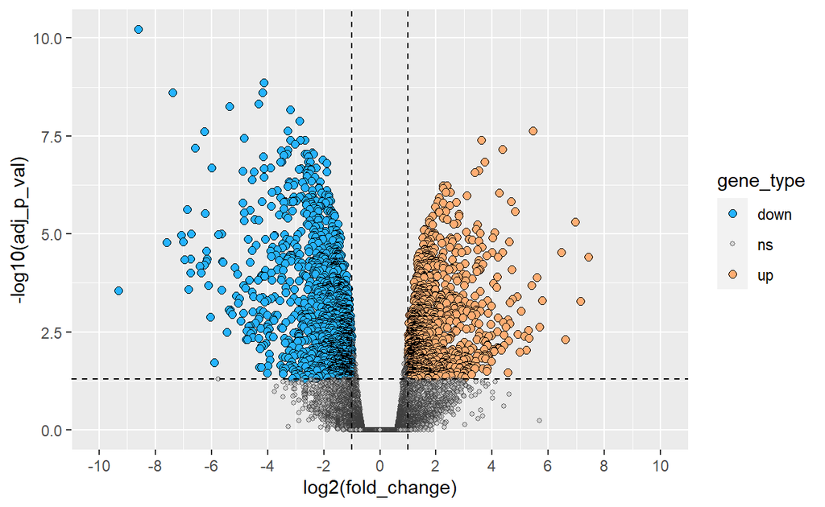

```r
# Add colour, size and alpha (transparency) to volcano plot --------------------
cols <- c("up" = "#ffad73", "down" = "#26b3ff", "ns" = "grey")
sizes <- c("up" = 2, "down" = 2, "ns" = 1)
alphas <- c("up" = 1, "down" = 1, "ns" = 0.5)

diseased_vs_healthy %>%
  ggplot(aes(x = log2(fold_change),
             y = -log10(adj_p_val),
             fill = gene_type,
             size = gene_type,
             alpha = gene_type)) +
  geom_point(shape = 21, # Specify shape and colour as fixed local parameters
             colour = "black") +
  geom_hline(yintercept = -log10(0.05),
             linetype = "dashed") +
  geom_vline(xintercept = c(log2(0.5), log2(2)),
             linetype = "dashed") +
  scale_fill_manual(values = cols) + # Modify point colour
  scale_size_manual(values = sizes) + # Modify point size
  scale_alpha_manual(values = alphas) + # Modify point transparency
  scale_x_continuous(breaks = c(seq(-10, 10, 2)),
                     limits = c(-10, 10))
```

# Layer subplots

You can also overlay subplots on top of your main plot. This is useful when you want to highlight a subset of your data using different colours, shapes and etc. When overlaying plots, you should not use `%>%` pipes but use global `ggplot(`data = “…”`)` and local `geom_point(data = ...)` arguments instead.

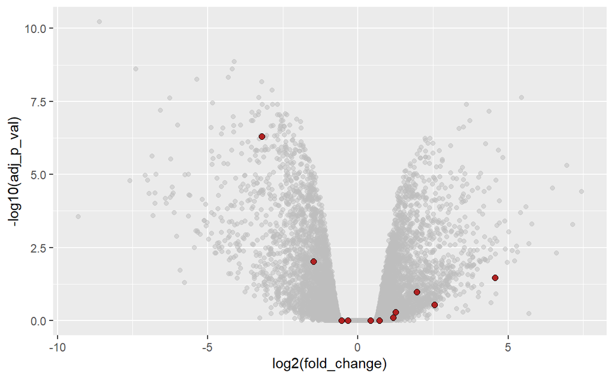

```r
# Add subplot layer to the main volcano plot -----------------------------------
ils <- str_subset(diseased_vs_healthy$symbol, "^[I|i]l[0-9]+$")

il_genes <- diseased_vs_healthy %>%
  filter(symbol %in% ils)

ggplot(data = diseased_vs_healthy, # Original data
       aes(x = log2(fold_change), y = -log10(adj_p_val))) +
  geom_point(colour = "grey", alpha = 0.5) +
  geom_point(data = il_genes, # New layer containing data subset il_genes
             size = 2,
             shape = 21,
             fill = "firebrick",
             colour = "black")
```

**Note:** Unless local aesthetics are specified, secondary `geom_point()` functions will inherit global ggplot aesthetics.

# Label points of interest

You can also label a subset of data using `geom_text()`, `geom_label()`, `geom_text_repel()` or `geom_label_repel` and by specifying which column to display as text using the local argument `geom_text(aes(label = ...))`.

**Note:** adjusting the parameters for optimal text separation using `geom_text_repel` can be a bit fiddly. I generally start by modifying force and then deciding which region of the plot I want to nudge my text or labels towards. You can read [this vignette](https://cran.r-project.org/web/packages/ggrepel/vignettes/ggrepel.html) for more tips on adjusting `geom_text_repel` parameters.

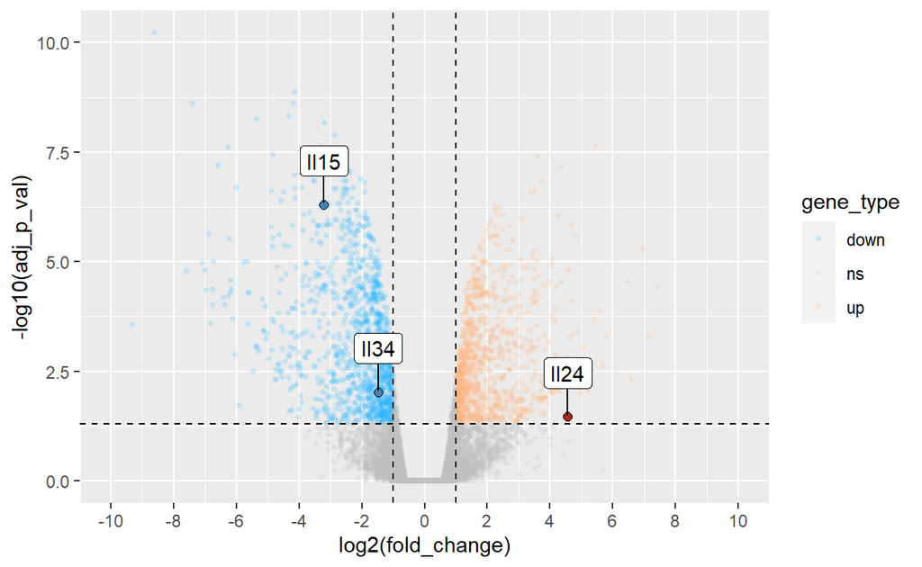

```r
# Layer more subplots ----------------------------------------------------------
sig_il_genes <- diseased_vs_healthy %>%
  filter(symbol %in% c("Il15", "Il34", "Il24"))

up_il_genes <- diseased_vs_healthy %>%
  filter(symbol == "Il24")

down_il_genes <- diseased_vs_healthy %>%
  filter(symbol %in% c("Il15", "Il34"))

ggplot(data = diseased_vs_healthy,
       aes(x = log2(fold_change),
           y = -log10(adj_p_val))) +
  geom_point(aes(colour = gene_type),
             alpha = 0.2,
             shape = 16,
             size = 1) +
  geom_point(data = up_il_genes,
             shape = 21,
             size = 2,
             fill = "firebrick",
             colour = "black") +
  geom_point(data = down_il_genes,
             shape = 21,
             size = 2,
             fill = "steelblue",
             colour = "black") +
  geom_hline(yintercept = -log10(0.05),
             linetype = "dashed") +
  geom_vline(xintercept = c(log2(0.5), log2(2)),
             linetype = "dashed") +
  geom_label_repel(data = sig_il_genes, # Add labels last to appear as the top layer
                   aes(label = symbol),
                   force = 2,
                   nudge_y = 1) +
  scale_colour_manual(values = cols) +
  scale_x_continuous(breaks = c(seq(-10, 10, 2)),
                     limits = c(-10, 10))
```

# Modify legend label positions

If you need to change the order of categorical figure legend values, you will need to `factor()` and re-level your categorical variable. This can be done using the `forcats` package, which allows you to easily modify factor levels.

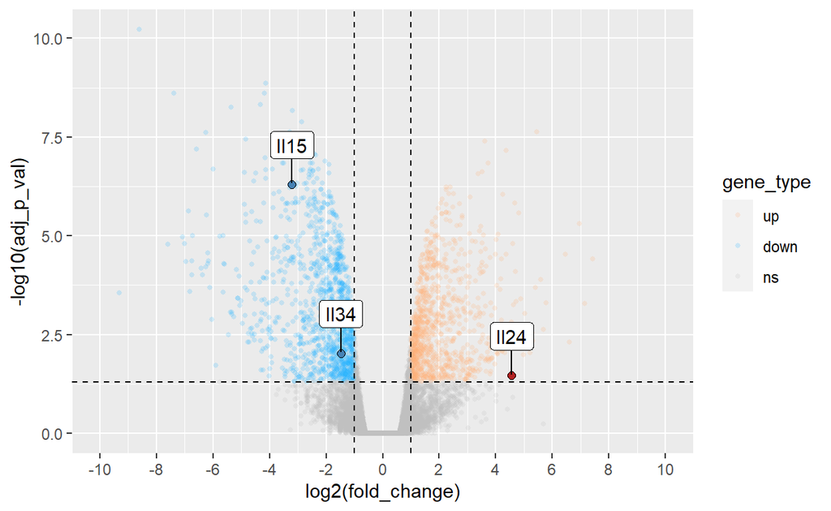

```r
# Modify legend labels by re-ordering gene_type levels -------------------------
diseased_vs_healthy <- diseased_vs_healthy %>%
  mutate(gene_type = fct_relevel(gene_type, "up", "down"))

# Recreate volcano plot --------------------------------------------------------
ggplot(data = diseased_vs_healthy,
       aes(x = log2(fold_change),
           y = -log10(adj_p_val))) +
  geom_point(aes(colour = gene_type),
             alpha = 0.2,
             shape = 16,
             size = 1) +
  geom_point(data = up_il_genes,
             shape = 21,
             size = 2,
             fill = "firebrick",
             colour = "black") +
  geom_point(data = down_il_genes,
             shape = 21,
             size = 2,
             fill = "steelblue",
             colour = "black") +
  geom_hline(yintercept = -log10(0.05),
             linetype = "dashed") +
  geom_vline(xintercept = c(log2(0.5), log2(2)),
             linetype = "dashed") +
  geom_label_repel(data = sig_il_genes,
                   aes(label = symbol),
                   force = 2,
                   nudge_y = 1) +
  scale_colour_manual(values = cols) +
  scale_x_continuous(breaks = c(seq(-10, 10, 2)),
                     limits = c(-10, 10))
```

# Modify plot labels and theme

The last finishing touches include modifying plot labels and the plot theme.

The function `labs()` is a handy way of organising all plot labels inside a single function. You can assign labels as `NULL` to prevent them from being displayed.

A plot can be further improved by changing its `theme()` and/or by modifying individual `theme()` parameters.

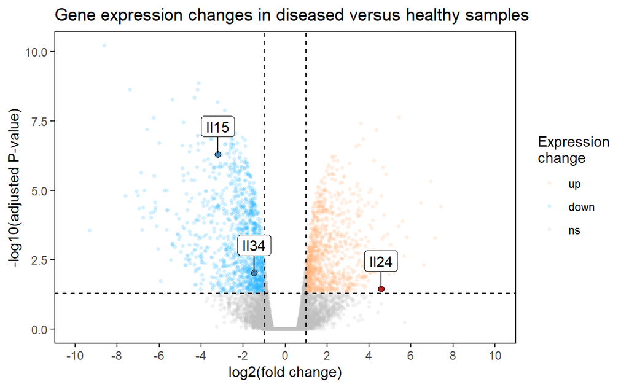

```r
# Add plot labels and modify plot theme ----------------------------------------
final_plot <- ggplot(data = diseased_vs_healthy,
       aes(x = log2(fold_change),
           y = -log10(adj_p_val))) +
  geom_point(aes(colour = gene_type),
             alpha = 0.2,
             shape = 16,
             size = 1) +
  geom_point(data = up_il_genes,
             shape = 21,
             size = 2,
             fill = "firebrick",
             colour = "black") +
  geom_point(data = down_il_genes,
             shape = 21,
             size = 2,
             fill = "steelblue",
             colour = "black") +
  geom_hline(yintercept = -log10(0.05),
             linetype = "dashed") +
  geom_vline(xintercept = c(log2(0.5), log2(2)),
             linetype = "dashed") +
  geom_label_repel(data = sig_il_genes,
                   aes(label = symbol),
                   force = 2,
                   nudge_y = 1) +
  scale_colour_manual(values = cols) +
  scale_x_continuous(breaks = c(seq(-10, 10, 2)),
                     limits = c(-10, 10)) +
  labs(title = "Gene expression changes in diseased versus healthy samples",
       x = "log2(fold change)",
       y = "-log10(adjusted P-value)",
       colour = "Expression \nchange") +
  theme_bw() + # Select theme with a white background
  theme(panel.border = element_rect(colour = "black", fill = NA, size= 0.5),
        panel.grid.minor = element_blank(),
        panel.grid.major = element_blank())

final_plot
```

**Note:** You can specify `panel.grid... = element_line(linetype = "dotted")` inside `theme()` to create dotted gridlines along the x and/or y axis. Major gridline positions are inherited from the values of axis breaks.

# Annotate text

You can add more descriptions to a plot by using the function `annotate()` to display text.

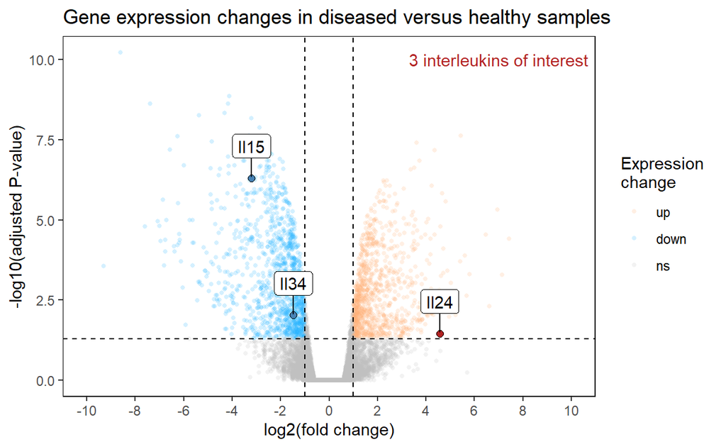

```r
# Annotate text inside plot ----------------------------------------------------
final_plot +
  annotate("text", x = 7, y = 10,
           label = "3 interleukins of interest", color = "firebrick")
```

# Other resources

- The excellent and interactive code-along [RStudio Cloud ggplot2 tutorials](https://rstudio.cloud/learn/primers/3)
- RStudio [`ggplot` cheatsheet](https://github.com/rstudio/cheatsheets/blob/master/data-visualization-2.1.pdf)
- STHDA [tutorial](http://www.sthda.com/english/wiki/ggplot2-axis-scales-and-transformations#axis-transformations) on `ggplot2` axis transformations
[^1]: The original coding logic should still be attributed to Chuanxin Liu, my former PhD student. I also recommend the excellent RStudio Cloud ggplot2 tutorials, which have taught me a few new tricks.